# TP1 Series Temporelles : Correction

Adrien Hardy

## Exercice 1

```r
n <- 500
t <- seq(1,n,1) # ou t <- 1:n
eps <- rnorm(n,0,1)
```

### Questions (a) et (b)

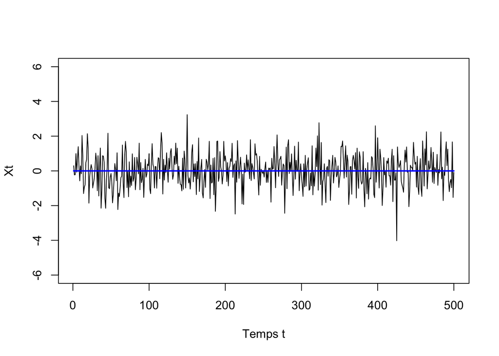

```r
# 1.
y1 <- eps
plot(y1,type='l',ylim=c(-6,6), xlab="Temps t",ylab="Xt")
lines(t*0, col='blue', lwd=2)
```

La période, tendance et saisonnalité sont données par :
$$T=1,\qquad m_t=s_t=0.$$

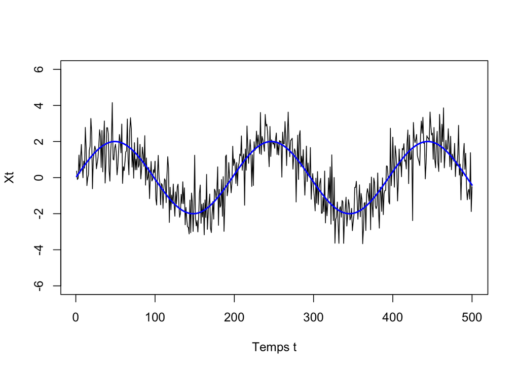

```r
# 2.
y2 <- 2*sin(0.1*t/pi)+eps
plot(y2,type='l',ylim=c(-6,6), xlab="Temps t",ylab="Xt")
lines(2*sin(0.1*t/pi),col='blue',lwd=2)
```

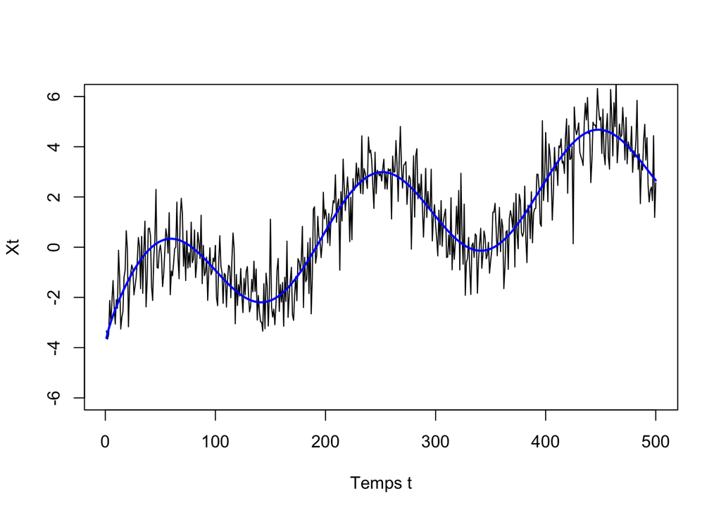

```r
# 3.
y3 <- sqrt(t/10)-4+2*sin(0.1*t/pi)+eps
plot(y3,type='l',ylim=c(-6,6), xlab="Temps t",ylab="Xt")
lines(sqrt(t/10)-4+2*sin(0.1*t/pi), type='l', col='blue', lwd=2)
```

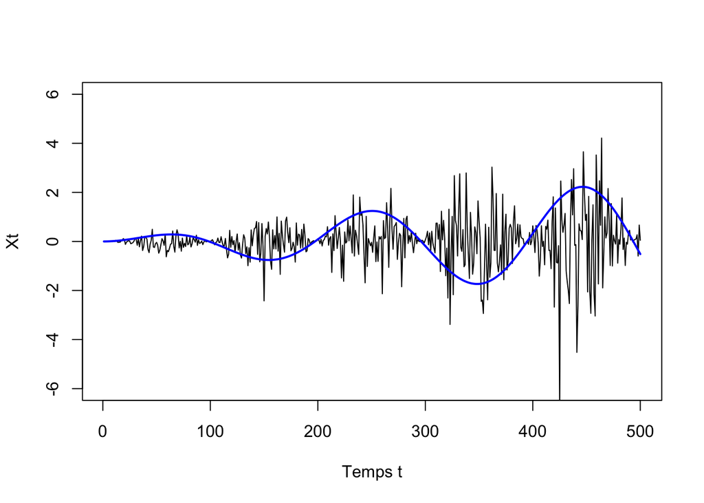

```r
# 4.
y4 <- t*sin(0.1*t/pi)*eps/200
plot(y4,type='l',ylim=c(-6,6), xlab="Temps t",ylab="Xt")
lines(t*sin(0.1*t/pi)/200, type='l', col='blue', lwd=2)
```

**Différence visuelle entre modèle additif et multiplicatif ?** On voit que, dans le cas multiplicatif, l’amplitude du bruit autour de la partie déterministe varie avec le temps, ce qui n’est pas le cas dans la décomposition additive.

### Question (c) [Partie théorique - Non demandée dans le compte-rendu]

Si l’équation $X_t=\frac12 X_{t-1}+\epsilon_t$, $t\in\mathbb{Z}$, a une solution $(X_t)_{t\in\mathbb Z}$, alors on voit par induction que
$$X_t=\sum_{k=0}^\infty \frac 1{2^k}\epsilon_{t-k}.\qquad\qquad (*)$$
Comme $(\epsilon_t)_{t\in\mathbb Z}$ est une suite de variables centrées réduites, on a par l’inégalité de Cauchy-Schwarz
$$\mathbb E|\epsilon_{i}||\epsilon_{j}|\leq (\mathbb E[\epsilon_{i}^2]\mathbb E[\epsilon_{j}^2])^{1/2}\leq 1$$
pour tout $i,j\in\mathbb Z$ et par conséquent
$$\mathbb E\left[\left(\sum_{k=0}^\infty \frac 1{2^k}|\epsilon_{t-k}|\right)^2\right]
=\sum_{k,l=0}^\infty\frac 1{2^{k+l}}\mathbb E[|\epsilon_{t-k}||\epsilon_{t-l}|]
\leq \sum_{k,l=0}^\infty\frac 1{2^{k+l}}
=\left(\sum_{k=0}^\infty\frac 1{2^{k}}\right)^2
=\left(\frac 1{1-\frac 12}\right)^2
=4<\infty,$$
où l’on a utilisé le théorème de Fubini-Tonelli et la convergence d’une série géométrique. Ainsi, la série définie en (*) existe bien dans $L^2$. En particulier, l’inégalité de Cauchy-Swcharz montre que $X_t$ a une espérance finie pour tout $t\in\mathbb Z$. De plus, comme $\mathbb E[\epsilon_t]=0$ pour tout $t\in\mathbb Z$, on voit que $\mathbb E[X_t]=0$ pour tout $t\in\mathbb Z$ car
$$\mathbb E[X_t]=\frac 12 \mathbb E[X_{t-1}]=\cdots=\frac 1{2^k} \mathbb E[X_{t-k}]\xrightarrow[k\to\infty]{} 0.$$
En utilisant que $\mathbb E[\epsilon_i\epsilon_j]=\delta_{ij}$, on calcule, pour tout $h\in\mathbb Z$ (faire le calcul quand $h\geq 0$ et $h<0$ séparément) :
$$Cov(X_t,X_{t+h})
=\mathbb E(X_tX_{t+h})
=\sum_{k,l=0}^\infty\frac 1{2^{k+l}}\mathbb E[\epsilon_{t-k}\epsilon_{t+h-l}]
=\frac 1{2^{|h|}}\sum_{k=0}^\infty\frac 1{2^{2k}}=\frac 1{2^{|h|}}\times \frac43,$$
et on obtient donc pour la fonction d’autocorrélation :
$$\rho(h)=\frac{Cov(X_t,X_{t+h})}{Var(X_t)}=\frac1{2^{|h|}},\qquad h\in\mathbb Z.$$

**Conclusion :** Le processus $(X_t)_{t\in\mathbb Z}$ existe dans $L^2$ et c’est un processus stationnaire.

### Question (c) [Partie simulation]

On crée une fonction :

```r
Process <- function(n){
  Z <- rnorm(2*n,0,1)
  X <- vector(,2*n)
  X[1] <- Z[1]
  for (t in 2:(2*n)){X[t] <- X[t-1]/2+ Z[t]}
  return(X[(n+1):(2*n)])
}
```

# Graphe du processus :

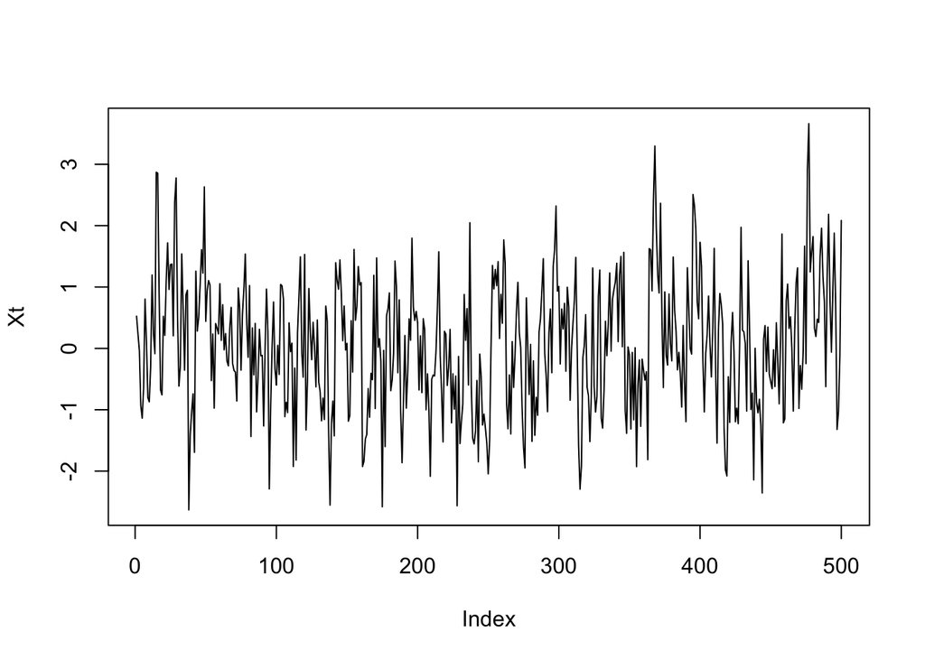

```r
Xt <- Process(500)
plot(Xt,type='l')
```

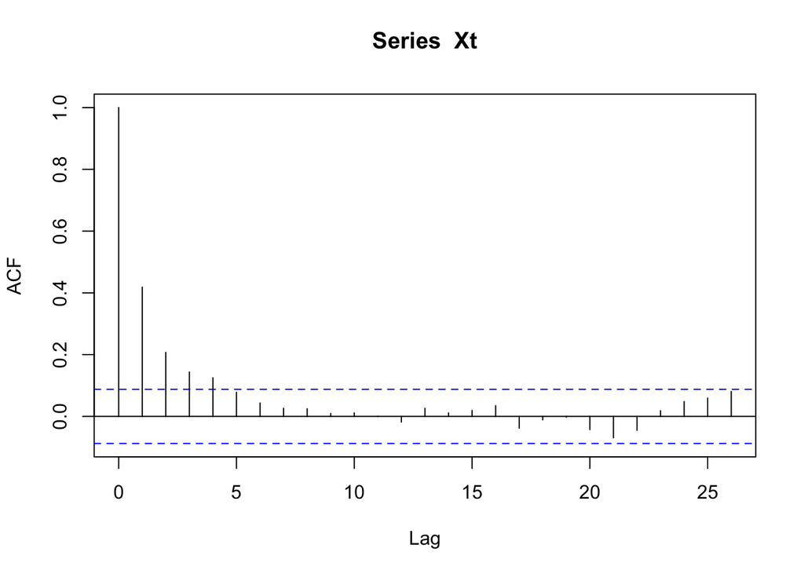

```r
# Fonction d'autocorrélation empirique :
acf(Xt)
```

## Exercice 2

### Question (a)

```r
str(EuStockMarkets)
```

```
##  Time-Series [1:1860, 1:4] from 1991 to 1999: 1629 1614 1607 1621 1618 ...
##  - attr(*, "dimnames")=List of 2
##   ..$ : NULL
##   ..$ : chr [1:4] "DAX" "SMI" "CAC" "FTSE"
```

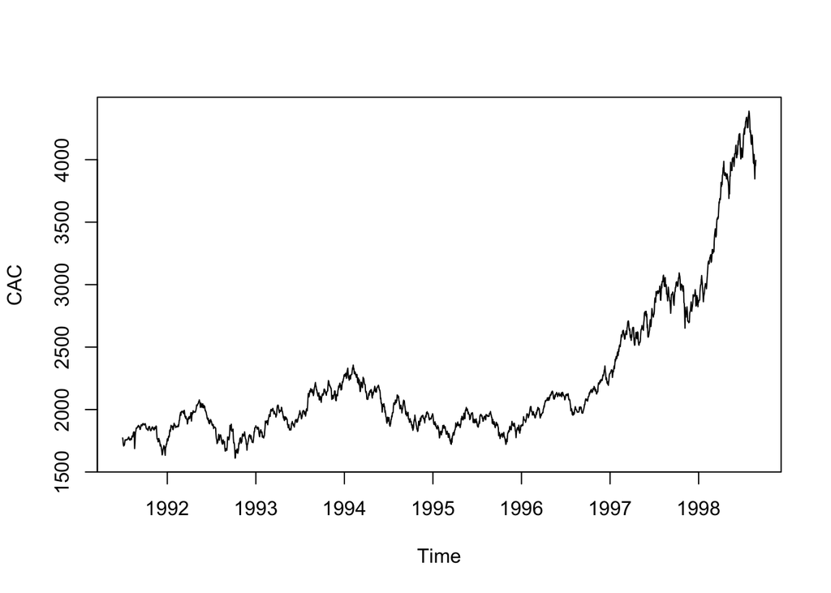

```r
CAC <- EuStockMarkets[,3]
plot(CAC)
```

On choisit de modéliser la série temporelle avec une décomposition additive :

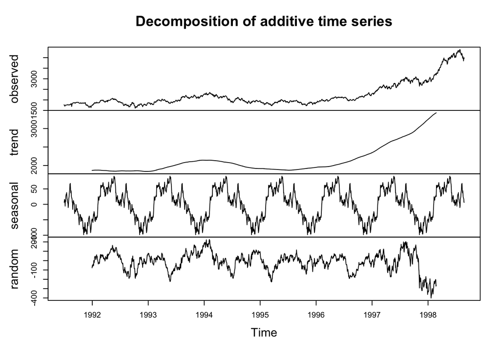

```r
Dec <- decompose(CAC,type="additive")
plot(Dec)
```

### Question (b)

```r
names(Dec)
```

```
## [1] "x"        "seasonal" "trend"    "random"   "figure"   "type"
```

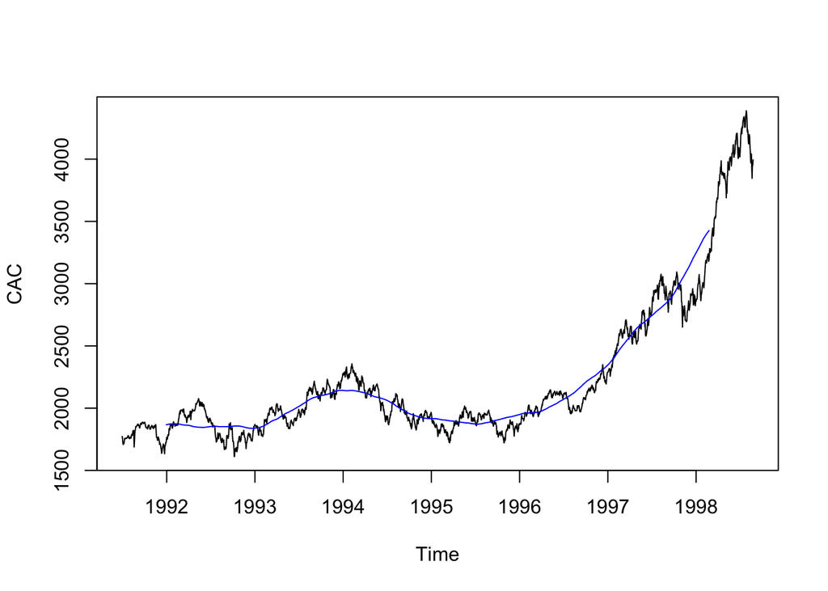

```r
mt <- Dec$trend
plot(CAC)
lines(mt, col='blue')
```

### Question (c)

```r
st <- Dec$seasonal
```

On trouve que la période $T=260$ en fouillant dans les détails de la commande $decompose$ : On y lit “Frequency = 260”. On peut aussi faire une petite boucle pour déterminer la période :

```r
for (i in 1:1000){if (st[i]==st[1]) print(i)}
```

```
## [1] 1
## [1] 261
## [1] 521
## [1] 781
```

```r
sum(st[1:260]) # 10^{-13} c'est essentiellement zéro...
```

```
## [1] -3.241851e-13
```

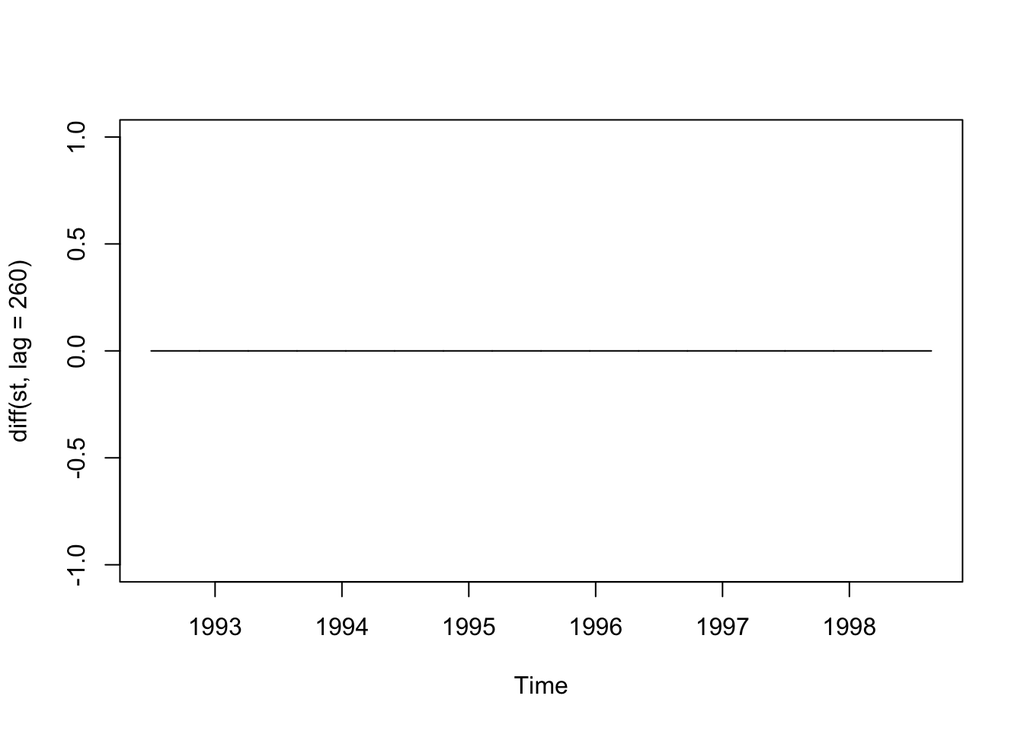

```r
plot(diff(st,lag=260))
```

La dernière commande représente la série $\Delta_{260}s_t=s_{t}-s_{t-260}$.

### Question (d)

```r
bruit <- Dec$random

help(mean)
mean(bruit,na.rm=TRUE)
```

```
## [1] -13.79223
```

```r
var(bruit,na.rm=TRUE)
```

```
## [1] 10165.99
```

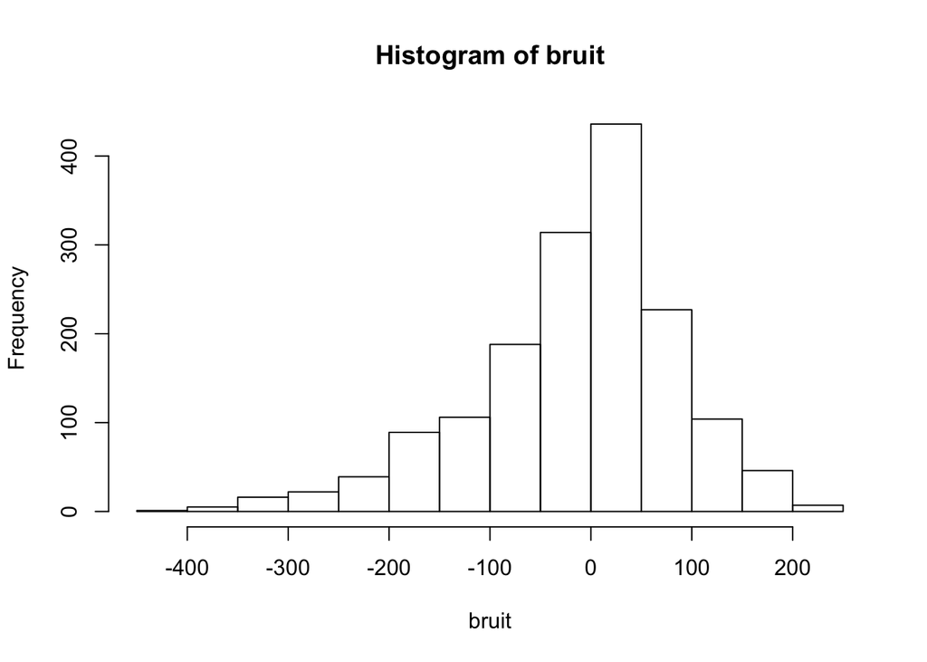

```r
hist(bruit)
```

### Question (e)

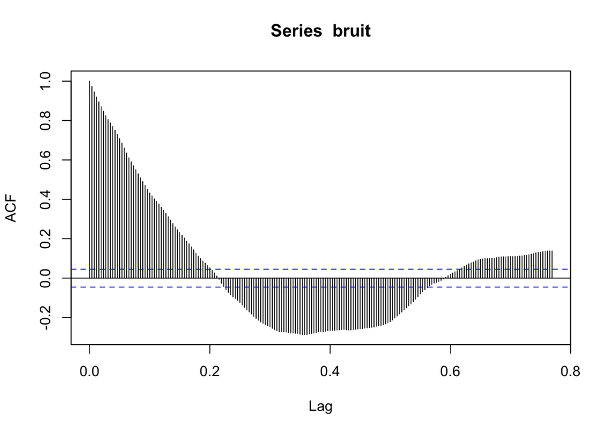

```r
help(acf)
acf(bruit, lag.max=200, na.action=na.pass)
```

```r
Box.test(bruit, lag=100, type="Ljung-Box")
```

```
##
##  Box-Ljung test
##
## data:  bruit
## X-squared = 27813, df = 100, p-value < 2.2e-16
```

?Box.test Le test de Ljung-Box (qui est jugé plus rapidement convergent que le test de Box-Pierce utilisé par défaut dans Box.test si on ne précise pas “type”) nous renvoie une p-value très petite devant $\alpha=0.05$ : on rejète l’hypothèse $H_0$ d’un bruit blanc i.i.d.